# The price prediction model of Airbnb in New York

Airbnb is the largest online short-term rental servies in the world (Falk, Larpin and Scaglione, 2019).By 2018, Airbnb has 4.5 million listings in the world. Price and location are the most important parameters in Airbnb literature . In recent years, many scholars showed their interest of Airbnb price setting. Some studies have found that prices of Airbnb accommodations are related to the internal characteristics of accommodation and external factors. Some studies consider the type of room as factors;location specific factors can also effect the price of accommodations (Chattopadhyay and Mitra, 2019).Besides, characteristics of Airbnb host is also important. Host has more than one listings can be expected to achieve higher price (Chen and Xie, 2017).

This study uses 2019 New York Airbnb data, which is download from Kaggle. The aim of this study is to explore the data and build price regression models to predict the price of Airbnb. This study is going to present the distribution of Airbnb accommodations in New York City and explain the characteristics of them. I will practice data cleaning, regression algorithms and feature engineering to achieve the lowest prediction error for the final model.

```python
import pandas as pd, numpy as np, matplotlib.pyplot as plt
import matplotlib.cm as cm, matplotlib.font_manager as fm
import seaborn as sns
import statsmodels
import statsmodels.api as sm
import scipy.stats as stats
from scipy.stats import norm
import urllib
```

### Loading data

The dataset has 48895 observations with 16 variables.There are six categorical variables and then numerical variables. It contains external characteristics of Airbnb accommodations, such as location, boroughs, as well as internal characteristics like room type, available days. Some individual variables have to be drop, because this study will not involve individual characteristics in the price prediction model.

```python
df = pd.read_csv('E:/AB_NYC_2019.csv', encoding='utf-8')
```

```python
df.head()
```

|  | id | name | host_id | host_name | neighbourhood_group | neighbourhood | latitude | longitude | room_type | price | minimum_nights | number_of_reviews | last_review | reviews_per_month | calculated_host_listings_count | availability_365 |
| --- | --- | --- | --- | --- | --- | --- | --- | --- | --- | --- | --- | --- | --- | --- | --- | --- |
| 0 | 2539 | Clean & quiet apt home by the park | 2787 | John | Brooklyn | Kensington | 40.64749 | -73.97237 | Private room | 149 | 1 | 9 | 2018-10-19 | 0.21 | 6 | 365 |
| 1 | 2595 | Skylit Midtown Castle | 2845 | Jennifer | Manhattan | Midtown | 40.75362 | -73.98377 | Entire home/apt | 225 | 1 | 45 | 2019-05-21 | 0.38 | 2 | 355 |
| 2 | 3647 | THE VILLAGE OF HARLEM....NEW YORK ! | 4632 | Elisabeth | Manhattan | Harlem | 40.80902 | -73.94190 | Private room | 150 | 3 | 0 | NaN | NaN | 1 | 365 |
| 3 | 3831 | Cozy Entire Floor of Brownstone | 4869 | LisaRoxanne | Brooklyn | Clinton Hill | 40.68514 | -73.95976 | Entire home/apt | 89 | 1 | 270 | 2019-07-05 | 4.64 | 1 | 194 |
| 4 | 5022 | Entire Apt: Spacious Studio/Loft by central park | 7192 | Laura | Manhattan | East Harlem | 40.79851 | -73.94399 | Entire home/apt | 80 | 10 | 9 | 2018-11-19 | 0.10 | 1 | 0 |

```python
print('Number of features: {}'.format(df.shape[1]))
print('Number of examples: {}'.format(df.shape[0]))
df.dtypes
```

```
Number of features: 16
Number of examples: 48895
```

```
id                                  int64
name                               object
host_id                             int64
host_name                          object
neighbourhood_group                object
neighbourhood                      object
latitude                          float64
longitude                         float64
room_type                          object
price                               int64
minimum_nights                      int64
number_of_reviews                   int64
last_review                        object
reviews_per_month                 float64
calculated_host_listings_count      int64
availability_365                    int64
dtype: object
```

### Data cleaning

In order to build regression model, it requires cleaning the null values and dropping irrelevant and insignificant features.Some features related to individual information need to be dropped, such as id,name, host name. This study focus on the neighbourhood group levels, so neighbourhood feature has been dropped. There are three features related to reviews. This study drops 'last_reviews' feature, which is related to date. There are four features containing null values. For "reviews_per_month" columns, null values occur where no reviews were given in the place.Therefore, I simply append it with 0 for null values, which means there is 0 rate of reviews per month.

```python
df.isnull().sum()
```

```
id                                    0
name                                 16
host_id                               0
host_name                            21
neighbourhood_group                   0
neighbourhood                         0
latitude                              0
longitude                             0
room_type                             0
price                                 0
minimum_nights                        0
number_of_reviews                     0
last_review                       10052
reviews_per_month                 10052
calculated_host_listings_count        0
availability_365                      0
dtype: int64
```

```python
#drop columns
df.drop(['id','host_name','last_review', 'neighbourhood', 'name'],axis = 1, inplace=True)
```

```python
#replace the missing values
df.fillna({'reviews_per_month':0}, inplace=True)
df.isnull().sum()
```

```
host_id                           0
neighbourhood_group               0
latitude                          0
longitude                         0
room_type                         0
price                             0
minimum_nights                    0
number_of_reviews                 0
reviews_per_month                 0
calculated_host_listings_count    0
availability_365                  0
dtype: int64
```

### Data exploration

This section is trying to explore and explain features in our dataset. It`s going to show the distribution of each feature and geographical distribution based on attributes.

#### Neighbourhood group

The chart below shows the distribution of Airbnb in New York. Most of Airbnb accommodations are located in Manhattan and Brooklyn.Staten Island only have 373 accommodations. From the map, it`s clear that Mahattan has the smallest land areas but has the most Airbnb accomodations and the highest density. The reason is that Manhattan is the business center as well as tourist destination.

```python
# Airbnb locations
neighbours = df['neighbourhood_group'].value_counts()
neighbours
```

```
Manhattan        21661
Brooklyn         20104
Queens            5666
Bronx             1091
Staten Island      373
Name: neighbourhood_group, dtype: int64
```

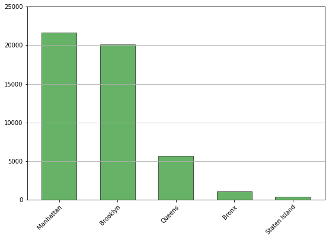

```python
ax = neighbours.plot(kind='bar', figsize=[9, 6], width=0.6, alpha=0.6,
                    color='g', edgecolor='k', grid=False, ylim=[0, 25000])

ax.set_xticklabels(neighbours.index, rotation=45, rotation_mode='anchor', ha='right')
ax.yaxis.grid(True)

plt.show()
```

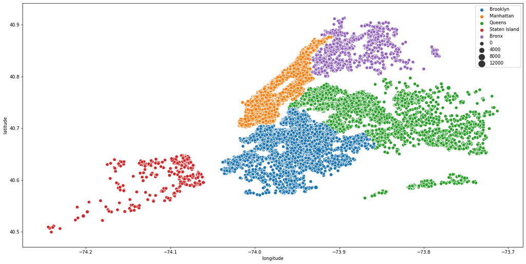

```python
X = df['longitude'].values
Y = df['latitude'].values
hue = df['neighbourhood_group'].values
size = df['price'].values
plt.figure(figsize=(20, 10))
sns.scatterplot(X, Y, hue=hue, size=size, sizes=(50, 200))
plt.xlabel('longitude')
plt.ylabel('latitude')
plt.legend(loc=0)
```

#### Room type

The proportions of entire home/apt and private room are very close. Entire home/apt is 3083 more than private room. Shared room only takes 2.37% of all Airbnb accommodations in New York. There is no significant difference in the geographical distribution of room type. It can tell from the result that customers are prefer entire home/apt and private than shared room.

```python
roomtype = df['room_type'].value_counts()
roomtype
```

```
Entire home/apt    25409
Private room       22326
Shared room         1160
Name: room_type, dtype: int64
```

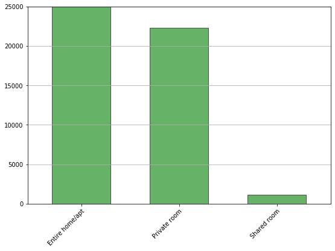

```python
ax = roomtype.plot(kind='bar', figsize=[9, 6], width=0.6, alpha=0.6,
                    color='g', edgecolor='k', grid=False, ylim=[0, 25000])

ax.set_xticklabels(roomtype.index, rotation=45, rotation_mode='anchor', ha='right')
ax.yaxis.grid(True)

plt.show()
```

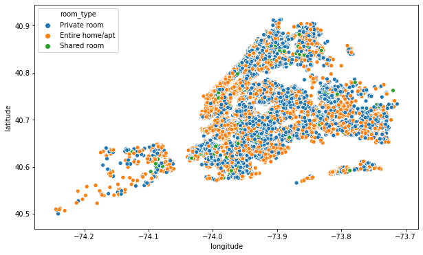

```python
plt.figure(figsize=(10,6))
sns.scatterplot(df.longitude,df.latitude,hue=df.room_type)
plt.ioff()
```

#### Longitude and latitude

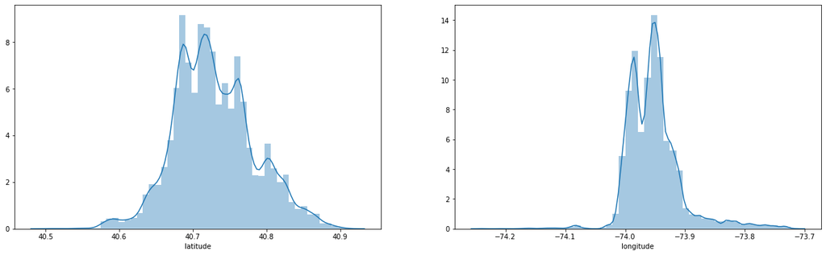

```python
#Location visualization
fig, axes = plt.subplots(1,2, figsize=(21,6))
sns.distplot(df['latitude'], ax=axes[0])
sns.distplot(df['longitude'], ax=axes[1])
```

#### Calculated host listings counts

The host who have most listing has 327 Airbnb accommodations. There are only four host have accommodations more than 100 in New York. The chart below shows the top ten host with the most listings in New York.

```python
top_host=df.host_id.value_counts().head(10)
top_host
```

```
219517861    327
107434423    232
30283594     121
137358866    103
12243051      96
16098958      96
61391963      91
22541573      87
200380610     65
7503643       52
Name: host_id, dtype: int64
```

[output not shown]

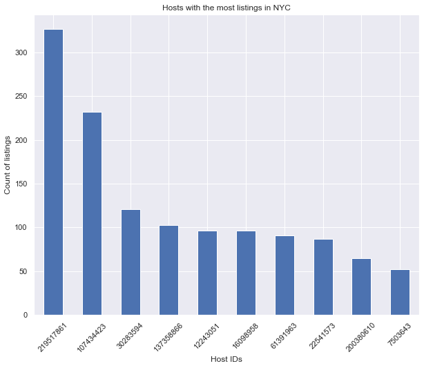

```python
sns.set(rc={'figure.figsize':(10,8)})
graph=top_host.plot(kind='bar')
graph.set_title('Hosts with the most listings in NYC')
graph.set_ylabel('Count of listings')
graph.set_xlabel('Host IDs')
graph.set_xticklabels(graph.get_xticklabels(), rotation=45)
```

#### Minimum stay

The range of minimum stay is from 0 to 400 days. There are only some accommodations requiring stay more than 400 days. This feature has skewed distribution, which may cause problems when building regression model. I made log transformation to make the distribution closer to normal. In the next section, I will examine if there is any outlier and remove them.

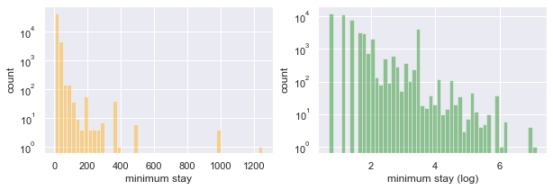

```python
fig, axes = plt.subplots(1,2, figsize=(10, 3))

sns.distplot(df['minimum_nights'], rug=False, kde=False, color="orange", ax = axes[0])
axes[0].set_yscale('log')
axes[0].set_xlabel('minimum stay')
axes[0].set_ylabel('count')
sns.distplot(np.log1p(df['minimum_nights']), rug=False, kde=False, color="green", ax = axes[1])
axes[1].set_yscale('log')
axes[1].set_xlabel('minimum stay (log)')
axes[1].set_ylabel('count')
```

#### Available 365

The distribution of available 365 is highly skewed. There are many accommodations only available a couple of days in the whole year and a large amount of accommodations available more than 300 days a year.

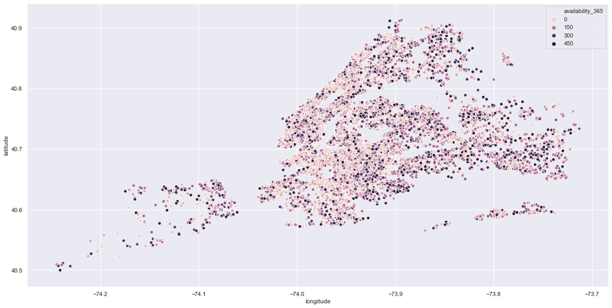

```python
#Available 365
X = df['longitude'].values
Y = df['latitude'].values
hue = df['availability_365']
size = df['price'].values
plt.figure(figsize=(20, 10))
sns.scatterplot(X, Y, hue=hue)
plt.xlabel('longitude')
plt.ylabel('latitude')
plt.legend(loc=0)
```

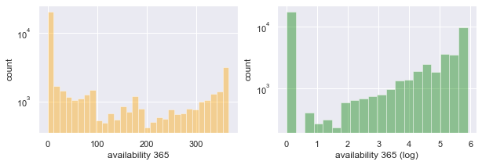

```python
fig, axes = plt.subplots(1,2, figsize=(10, 3))

sns.distplot(df['availability_365'], rug=False, kde=False, color="orange", ax = axes[0])
axes[0].set_yscale('log')
axes[0].set_xlabel('availability 365')
axes[0].set_ylabel('count')
sns.distplot(np.log1p(df['availability_365']), rug=False, kde=False, color="green", ax = axes[1])
axes[1].set_yscale('log')
axes[1].set_xlabel('availability 365 (log)')
axes[1].set_ylabel('count')
```

#### Reviews per month

The distribution of reviews per month is also highly skewed. There are lots of Airbnb accommodations only getting less than 10 reviews a month. There is also a long tail that some Airbnb accommodations got many reviews a month. I made square root transformation to try to make the distribution more normal.

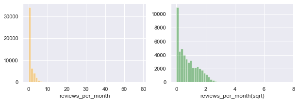

```python
#reviews per month
fig, axes = plt.subplots(1,2,figsize=(10, 3))
sns.distplot(df['reviews_per_month'], rug=False, kde=False, color="orange", ax=axes[0])
sns.distplot(np.sqrt(df['reviews_per_month']), rug=False, kde=False, color="green", ax=axes[1])
axes[1].set_xlabel('reviews_per_month(sqrt)')
```

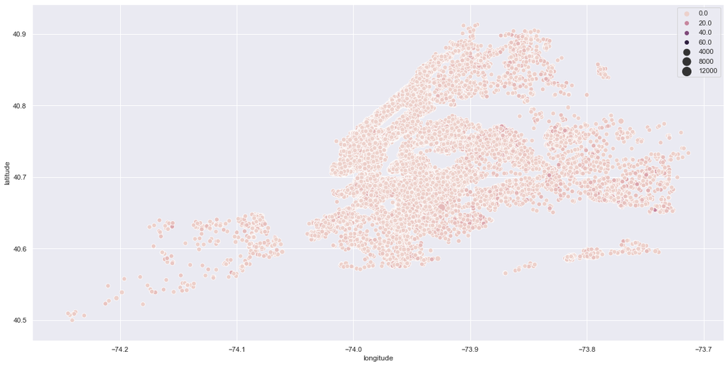

```python
X = df['longitude'].values
Y = df['latitude'].values
hue = df['reviews_per_month'].values
size = df['price'].values
plt.figure(figsize=(20, 10))
sns.scatterplot(X, Y, hue=hue, size=size, sizes=(50, 200))
plt.xlabel('longitude')
plt.ylabel('latitude')
plt.legend(loc=0)
```

#### Numer of reviews

Most of airbnb accommodations just have a couple of reviews. There is a long tail that few accommodations have reviews more than 100. Over 10000 Airbnb accommodations have no review. There are maybe correlation between number of reviews and reviews per month, which may cause problems to regression model. In the next section, I will examine correlations between features and multicollinearity.

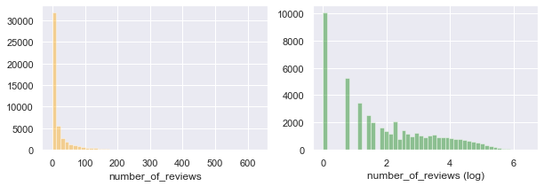

```python
fig, axes = plt.subplots(1,2,figsize=(10, 3))
sns.distplot(df['number_of_reviews'], rug=False, kde=False, color="orange", ax=axes[0])
sns.distplot(np.log1p(df['number_of_reviews']), rug=False, kde=False, color="green", ax=axes[1])
axes[1].set_xlabel('number_of_reviews (log)')
```

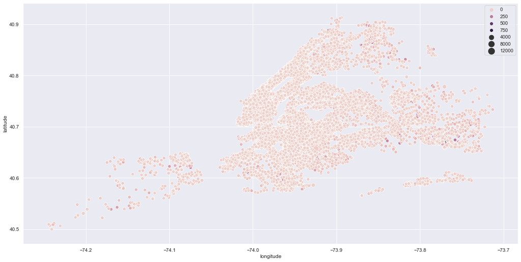

```python
X = df['longitude'].values
Y = df['latitude'].values
hue = df['number_of_reviews'].values
size = df['price'].values
plt.figure(figsize=(20, 10))
sns.scatterplot(X, Y, hue=hue, size=size, sizes=(50, 200))
plt.xlabel('longitude')
plt.ylabel('latitude')
plt.legend(loc=0)
```

#### Price

Price is the dependent variable of our regression model. Most of price of Airbnb accommodations are from 0 to 500. The long tail indicates that there are few accommodations have high price. I made logarithmic transformation to get the normal distribution and dropped extreme values.From the Q-Q plot is easily to tell that the points are almost identical to line y = x after logarithmic transformation and removing extreme values. Therefore, this study only involves Airbnb accommodations which price is under 500.

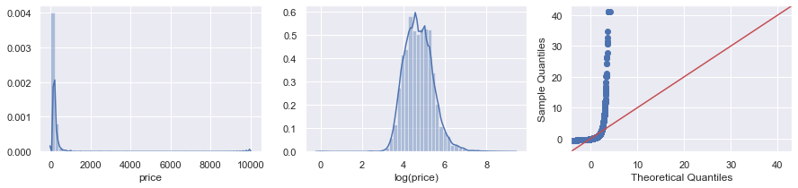

[figure not shown]

```python
fig, axes = plt.subplots(1,3, figsize=(15,3))
sns.distplot(df['price'], ax=axes[0])
sns.distplot(np.log1p(df['price']), ax=axes[1])
axes[1].set_xlabel('log(price)')
sm.qqplot(df['price'], stats.norm, fit=True, line='45', ax=axes[2])
```

```python
df = df[df['price'] < 500]
```

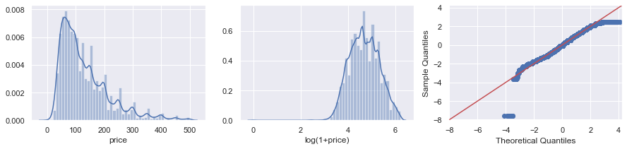

[figure not shown]

```python
fig, axes = plt.subplots(1,3, figsize=(15,3))
sns.distplot(df['price'], ax=axes[0])
sns.distplot(np.log1p(df['price']), ax=axes[1])
axes[1].set_xlabel('log(1+price)')
sm.qqplot(np.log1p(df['price']), stats.norm, fit=True, line='45', ax=axes[2])
```

### Price and room type

The statistic table and violin plot below shows the distribution of prices for different room type.Entire home/apt has the highest and widest range of price, with 155 dollars as median price and 219 dollars as third quantiles price.Private room and shared room have similar distribution. The prices of these two types accommodation is usually under 100 dollars, but private room is more expensive than shared room.

```python
#Entire home
sub_7=df.loc[df['room_type'] == 'Entire home/apt']
price_sub7=sub_7[['price']]
#Private room
sub_8=df.loc[df['room_type'] == 'Private room']
price_sub8=sub_8[['price']]
# Shared room
sub_9=df.loc[df['room_type'] == 'Shared room']
price_sub9=sub_9[['price']]
roomtype_price=[price_sub7, price_sub8, price_sub9]
```

```python
price_type=[]
name_list=['Entire home/apt', 'Private room', 'Shared room']
for x in roomtype_price:
    i=x.describe(percentiles=[.25, .50, .75])
    i=i.iloc[3:]
    i.reset_index(inplace=True)
    i.rename(columns={'index':'Stats'}, inplace=True)
    price_type.append(i)
price_type[0].rename(columns={'price':name_list[0]}, inplace=True)
price_type[1].rename(columns={'price':name_list[1]}, inplace=True)
price_type[2].rename(columns={'price':name_list[2]}, inplace=True)
stat_df1=price_type
stat_df1=[df.set_index('Stats') for df in stat_df1]
stat_df1=stat_df1[0].join(stat_df1[1:])
stat_df1
```

| Stats | Entire home/apt | Private room | Shared room |
| --- | --- | --- | --- |
| min | 0.0 | 0.0 | 0.0 |
| 25% | 119.0 | 50.0 | 33.0 |
| 50% | 155.0 | 70.0 | 45.0 |
| 75% | 219.0 | 95.0 | 75.0 |
| max | 499.0 | 499.0 | 450.0 |

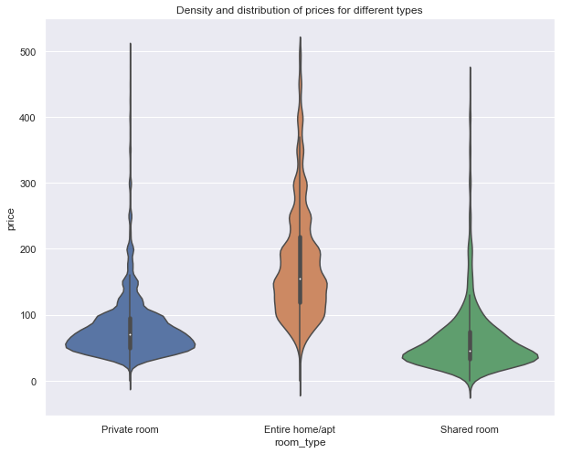

```python
price_roomtype=sns.violinplot(data=df[df.price < 500], x='room_type', y='price')
price_roomtype.set_title('Density and distribution of prices for different types')
```

#### Price and neighbourhood group

From the statistic table, map and violin plots, it`s clear that Manhattan has the highest range of prices, with 143 dollars median price. Brooklyn, Queens, Bronx and Staten Island show the similar distribution. Accommodations in Brooklyn are more expensive than the rest three boroughs. Bronx is the cheapest area of five boroughs, with 65 median price.The map shows the geographical heatmap of price based on latitude and longitude.

```python
##Price location
#Brooklyn
sub_1=df.loc[df['neighbourhood_group'] == 'Brooklyn']
price_sub1=sub_1[['price']]
#Manhattan
sub_2=df.loc[df['neighbourhood_group'] == 'Manhattan']
price_sub2=sub_2[['price']]
#Queens
sub_3=df.loc[df['neighbourhood_group'] == 'Queens']
price_sub3=sub_3[['price']]
#Staten Island
sub_4=df.loc[df['neighbourhood_group'] == 'Staten Island']
price_sub4=sub_4[['price']]
#Bronx
sub_5=df.loc[df['neighbourhood_group'] == 'Bronx']
price_sub5=sub_5[['price']]
neighbourhood_price=[price_sub1, price_sub2, price_sub3, price_sub4, price_sub5]
```

```python
price_ne=[]

nei_list=['Brooklyn', 'Manhattan', 'Queens', 'Staten Island', 'Bronx']

for x in neighbourhood_price:
    i=x.describe(percentiles=[.25, .50, .75])
    i=i.iloc[3:]
    i.reset_index(inplace=True)
    i.rename(columns={'index':'Stats'}, inplace=True)
    price_ne.append(i)

price_ne[0].rename(columns={'price':nei_list[0]}, inplace=True)
price_ne[1].rename(columns={'price':nei_list[1]}, inplace=True)
price_ne[2].rename(columns={'price':nei_list[2]}, inplace=True)
price_ne[3].rename(columns={'price':nei_list[3]}, inplace=True)
price_ne[4].rename(columns={'price':nei_list[4]}, inplace=True)

stat_df=price_ne
stat_df=[df.set_index('Stats') for df in stat_df]
stat_df=stat_df[0].join(stat_df[1:])
stat_df
```

| Stats | Brooklyn | Manhattan | Queens | Staten Island | Bronx |
| --- | --- | --- | --- | --- | --- |
| min | 0.0 | 0.0 | 10.0 | 13.0 | 0.0 |
| 25% | 60.0 | 91.0 | 50.0 | 50.0 | 45.0 |
| 50% | 90.0 | 143.0 | 75.0 | 75.0 | 65.0 |
| 75% | 146.0 | 200.0 | 110.0 | 105.5 | 99.0 |
| max | 499.0 | 499.0 | 499.0 | 450.0 | 475.0 |

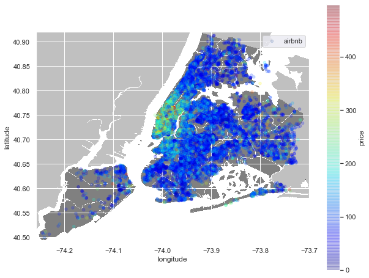

```python
plt.figure(figsize=(10,8))
i=urllib.request.urlopen('https://upload.wikimedia.org/wikipedia/commons/e/ec/Neighbourhoods_New_York_City_Map.PNG')
nyc_img=plt.imread(i)
plt.imshow(nyc_img,zorder=0,extent=[-74.258, -73.7, 40.49,40.92])
ax=plt.gca()
df.plot(kind='scatter', x='longitude', y='latitude', label='airbnb', c='price', ax=ax,
           cmap=plt.get_cmap('jet'), colorbar=True, alpha=0.2, zorder=5)
plt.legend()
plt.show()
```

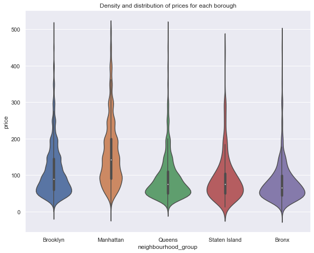

```python
price_neighbourhood_group=sns.violinplot(data=df[df.price < 500], x='neighbourhood_group', y='price')
price_neighbourhood_group.set_title('Density and distribution of prices for each borough')
```

#### Room type and neighbourhood group

The graph shows the distribution of room type in five boroughs. Different from other boroughs, entire room/apt has the largest proportion in Manhattan, with more than 12000 accommodations. The number of private room in Manhattan is less than that in Brooklyn. In other four boroughs, private room has the largest proportion. There are few shared room in Staten Island and Bronx.

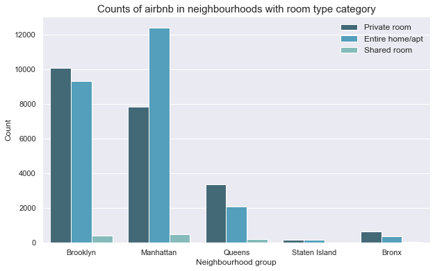

```python
plt.figure(figsize=(10,6))
sns.countplot(data=df, x='neighbourhood_group', hue='room_type', palette='GnBu_d')
plt.title('Counts of airbnb in neighbourhoods with room type category', fontsize=15)
plt.xlabel('Neighbourhood group')
plt.ylabel("Count")
plt.legend(frameon=False, fontsize=12)
```

### Bivariate correlations

The matrix shows the correlations between numerical features in the dataset. There is no strong correlations between features. The number of reviews is 60% correlated with the number of reviews per month; the price is 30% correlated with longitude, because the high price accommodations are located at the Manhattan. The host id conlume need to dropped, because it is not related to price.

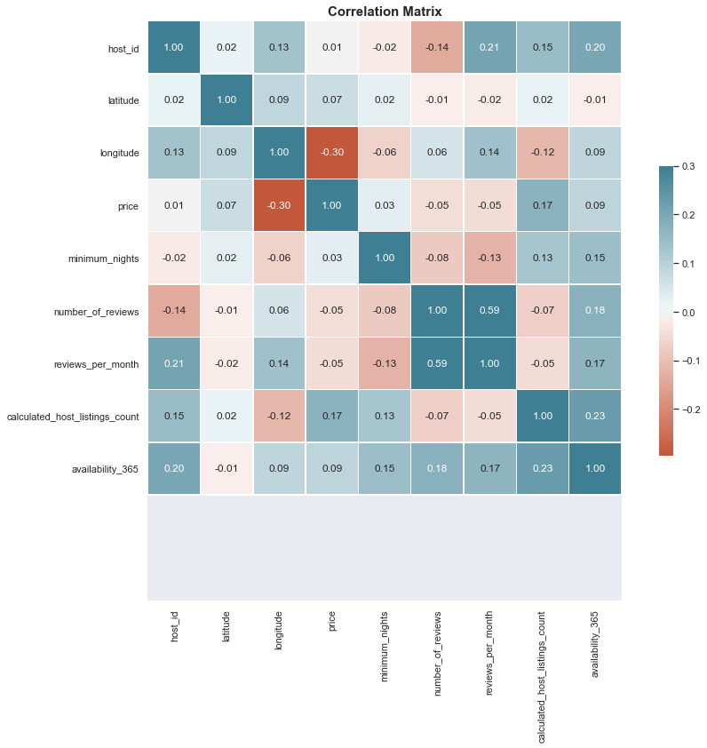

```python
plt.figure(figsize=(15,12))
palette = sns.diverging_palette(20, 220, n=256)
corr=df.corr(method='pearson')
sns.heatmap(corr, annot=True, fmt=".2f", cmap=palette, vmax=.3, center=0,
            square=True, linewidths=.5, cbar_kws={"shrink": .5}).set(ylim=(11, 0))
plt.title("Correlation Matrix",size=15, weight='bold')
```

In order to build regression model, it needs to remove outliers as well as examine multicollinearity. The scatter plots show the correlations of four numerical variables with price. The outliers will appear at the right of red line. There is no outlier observed in the plot. Multicollinearity will help to measure the relationship between explanatory variables in multiple regression. If there is multicollinearity occurs, these highly related input variables should be eliminated from the model.None of the result is closed to zero. It means there is no multicollinearity in the data.

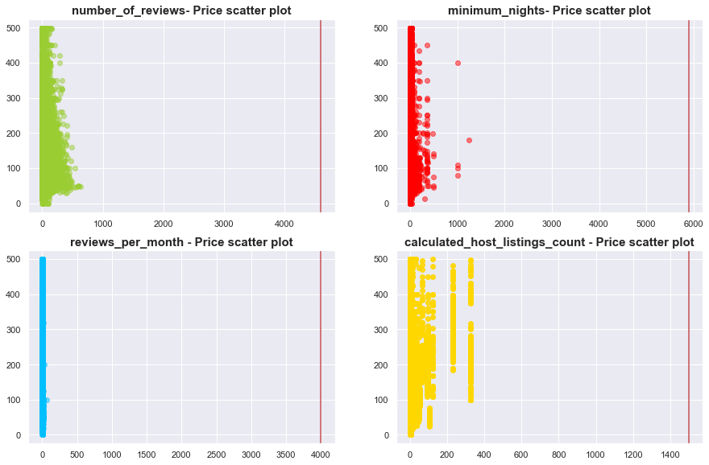

```python
fig = plt.figure(figsize=(15,15))
ax1 = plt.subplot2grid((3,2),(0,0))
plt.scatter(x=df['number_of_reviews'], y=df['price'], color=('yellowgreen'), alpha=0.5)
plt.axvline(x=4600, color='r', linestyle='-')
plt.title('number_of_reviews- Price scatter plot', fontsize=15, weight='bold' )

ax1 = plt.subplot2grid((3,2),(0,1))
plt.scatter(x=df['minimum_nights'], y=df['price'], color=('red'),alpha=0.5)
plt.axvline(x=5900, color='r', linestyle='-')
plt.title('minimum_nights- Price scatter plot', fontsize=15, weight='bold' )

ax1 = plt.subplot2grid((3,2),(1,0))
plt.scatter(x=df['reviews_per_month'], y=df['price'], color=('deepskyblue'),alpha=0.5)
plt.axvline(x=4000, color='r', linestyle='-')
plt.title('reviews_per_month - Price scatter plot', fontsize=15, weight='bold' )

ax1 = plt.subplot2grid((3,2),(1,1))
plt.scatter(x=df['availability_365'], y=df['price'], color=('gold'),alpha=0.9)
plt.axvline(x=1500, color='r', linestyle='-')
plt.title('availability_365 - Price scatter plot', fontsize=15, weight='bold' )

ax1 = plt.subplot2grid((3,2),(1,1))
plt.scatter(x=df['calculated_host_listings_count'], y=df['price'], color=('gold'),alpha=0.9)
plt.axvline(x=1500, color='r', linestyle='-')
plt.title('calculated_host_listings_count - Price scatter plot', fontsize=15, weight='bold' )
```

```python
multicollinearity, V=np.linalg.eig(corr)
multicollinearity
```

```
array([1.78109102, 1.52700275, 0.30947755, 1.26146232, 0.59318639,
       0.76196242, 0.71862435, 1.01797283, 1.02922037])
```

```python
df.drop(['host_id'],axis = 1, inplace=True)
```

#### Feature engineering

In order to build regression model, it needs to encode the categorical variables to number. There are two categorical variables included in the model: neighbourhood group and room type.

```python
categorical_features = df.select_dtypes(include=['object'])
print('Categorical features: {}'.format(categorical_features.shape))
```

```
Categorical features: (47660, 2)
```

```python
def Encode(df):
    for column in df.columns[df.columns.isin(['neighbourhood_group', 'room_type'])]:
        df[column] = df[column].factorize()[0]
    return df

df_en = Encode(df.copy())
```

```python
df_en.head(5)
```

|  | neighbourhood_group | latitude | longitude | room_type | price | minimum_nights | number_of_reviews | reviews_per_month | calculated_host_listings_count | availability_365 |
| --- | --- | --- | --- | --- | --- | --- | --- | --- | --- | --- |
| 0 | 0 | 40.64749 | -73.97237 | 0 | 149 | 1 | 9 | 0.21 | 6 | 365 |
| 1 | 1 | 40.75362 | -73.98377 | 1 | 225 | 1 | 45 | 0.38 | 2 | 355 |
| 2 | 1 | 40.80902 | -73.94190 | 0 | 150 | 3 | 0 | 0.00 | 1 | 365 |
| 3 | 0 | 40.68514 | -73.95976 | 1 | 89 | 1 | 270 | 4.64 | 1 | 194 |
| 4 | 1 | 40.79851 | -73.94399 | 1 | 80 | 10 | 9 | 0.10 | 1 | 0 |

The matrix shows the correlation between all variables. Latitude is fairly (50%) correlated with neighbourhood group.Price is 48% correlated with room type.Entire room/apt is expected to have high price than private room and shared room. Number of reviews and reviews per month also have high correlation. Because there is no multicollinearity in the data, we don`t need to drop these two variables.

```
Index(['neighbourhood_group', 'latitude', 'longitude', 'room_type', 'price',
       'minimum_nights', 'number_of_reviews', 'reviews_per_month',
       'calculated_host_listings_count', 'availability_365'],
      dtype='object')
```

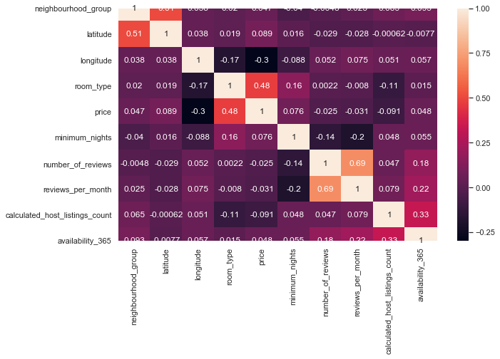

```python
corr = df_en.corr(method='kendall')
plt.figure(figsize=(10,6))
sns.heatmap(corr, annot=True)
df_en.columns
```

Log transformation is used to make the skewed distribution to normal distribution.

```python
df['price'] = np.log1p(df['price'])
```

```python
df['minimum_nights'] = np.log1p(df['minimum_nights'])
```

```python
df['number_of_reviews'] = np.log1p(df['number_of_reviews'])
```

#### Regression model

After data cleaning and feature engineering, the price prediction model includes nine independent variables.The data has been split in train and test sets with 80-20 ratio. We use the training set to train the model and use the testing model to test the accuracy of the model. The train set has 38128 observations and test set has 9532 observations. For the start, I will try the basic regression model: Linear regression.

```python
from scipy.stats import norm
from scipy import stats
from sklearn import preprocessing
from sklearn.preprocessing import LabelEncoder
from sklearn.model_selection import train_test_split
from sklearn.model_selection import GridSearchCV
from sklearn.linear_model import LinearRegression
from sklearn.linear_model import Ridge
from sklearn.linear_model import Lasso
from sklearn.linear_model import ElasticNet
from sklearn import metrics
from sklearn.metrics import mean_squared_error
from sklearn.metrics import mean_absolute_error
from math import sqrt
from sklearn.metrics import r2_score
```

```python
x = df_en.iloc[:,[0,1,2,3,5,6,7,8,9]]
y = df_en['price']
x_train,x_test,y_train,y_test=train_test_split(x,y,test_size=0.2,random_state=28)
x_train.head()
y_train.head()
```

```
7156     130
29027    125
18269     95
43918    175
8634     139
Name: price, dtype: int64
```

```python
x_train.shape
```

```
(38128, 9)
```

```python
x_test.shape
```

```
(9532, 9)
```

The chart shows the importance of each variables in the model. Neighbourhood group and room type have the lowest importance of this model. Longitude and latitude have the highest importance.

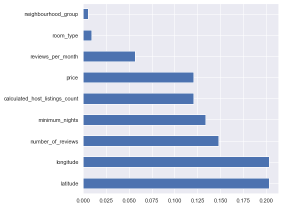

```python
lab_enc = preprocessing.LabelEncoder()

feature_model = ExtraTreesClassifier(n_estimators=50)
feature_model.fit(x_train,lab_enc.fit_transform(y_train))

plt.figure(figsize=(7,7))
feat_importances = pd.Series(feature_model.feature_importances_, index=df_en.iloc[:,:9].columns)
feat_importances.nlargest(10).plot(kind='barh')
plt.show()
```

The result shows prediction results of linear regression. It shows coefficient and intercept of linear regression model. The mean absolute error (MAE) result shows the prediction error of the model;root mean square error (RMSE) shows how much error the system typically makes in its predictions;R-square represents the proportion of the variance for a dependent variable that's explained by an independent variable.It is clear that linear regression model has significant errors of price prediction. 28% of the data fits the linear regression model. In next section, I will try other regression models to avoid over-fitting.

```python
#Linear
reg=LinearRegression()
reg.fit(x_train,y_train)
y_pred=reg.predict(x_test)
from sklearn.metrics import r2_score
print(r2_score(y_test,y_pred))
print("reg.coef_: {}".format(reg.coef_))
print("reg.intercept_: {}".format(reg.intercept_))
print('MAE: %f'% mean_absolute_error(y_test,y_pred))
print('RMSE: %f'% np.sqrt(mean_squared_error(y_test,y_pred)))
print('r^2 on test data %f' % r2_score(y_test,y_pred))
```

```
0.2860622005497955
reg.coef_: [-6.66335274e-01  1.43920731e+02 -4.32491651e+02  6.44753695e+01
 -2.06075203e-01 -7.12144816e-02  1.48690973e-01  2.23195395e-01
  6.56661425e-02]
reg.intercept_: -37756.75434735461
MAE: 49.972716
RMSE: 72.708965
r^2 on test data 0.286062
```

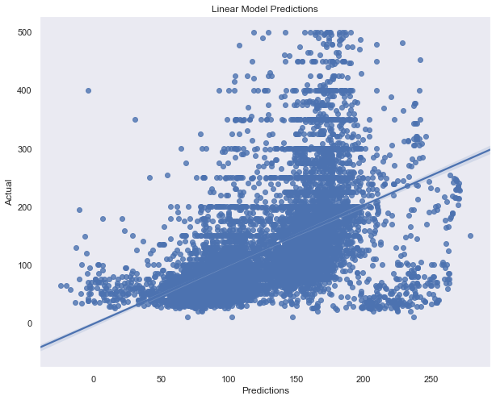

```python
plt.figure(figsize=(10,8))
sns.regplot(y_pred,y_test)
plt.xlabel('Predictions')
plt.ylabel('Actual')
plt.title("Linear Model Predictions")
plt.grid(False)
plt.show()
```

### Regularization

Lasso regression, ridge regression and ElasicNet regression are built to avoid over-fitting of basic linear regression model. The first step is to find a value of alpha that minimizes the train and test error. GridSearchCV algorithm is used to find the best alpha for each model.

ElasticNet regression combines both ridge and lasso regression. It needs to set ratio between ridge and lasso to get a better combination of both.

```python
import math
import sklearn.model_selection as GridSearchCV
import sklearn.model_selection as ms

ridge=Ridge()
parameters= {'alpha':[x for x in range(1,101)]}

ridge_reg=ms.GridSearchCV(ridge, param_grid=parameters, scoring='neg_mean_squared_error', cv=15)
ridge_reg.fit(x_train,y_train)
print("The best value of Alpha is: ",ridge_reg.best_params_)
print("The best score achieved with Alpha=11 is: ",math.sqrt(-ridge_reg.best_score_))
ridge_pred=math.sqrt(-ridge_reg.best_score_)
```

[output not shown]

```python
#Lasso
parameters= {'alpha':[0.0001,0.0009,0.001,0.002,0.003,0.01,0.1,1,10,100]}

lasso=Lasso()
lasso_reg=ms.GridSearchCV(lasso, param_grid=parameters, scoring='neg_mean_squared_error', cv=15)
lasso_reg.fit(x_train,y_train)

print('The best value of Alpha is: ',lasso_reg.best_params_)
```

```
The best value of Alpha is:  {'alpha': 0.0001}
```

```python
from sklearn.linear_model import ElasticNetCV
import sklearn.metrics as sklm
alphas = [10,1,0.1,0.01,0.001,0.002,0.003,0.004,0.005,0.00054255]
l1ratio = [0.1, 0.3,0.5, 0.9, 0.95, 0.99, 1]

elastic_cv = ElasticNetCV(cv=5, max_iter=1e7, alphas=alphas,  l1_ratio=l1ratio)

elasticmod = elastic_cv.fit(x_train, y_train.ravel())
ela_pred=elasticmod.predict(x_test)
print('Root Mean Square Error test = ' + str(math.sqrt(sklm.mean_squared_error(y_test, ela_pred))))
print(elastic_cv.alpha_)
```

```
Root Mean Square Error test = 72.71077873882473
0.00054255
```

```python
#Lasso
alpha = 0.002
lasso = Lasso(alpha=alpha)
y_pred_lasso = lasso.fit(x_train, y_train).predict(x_test)
r2_score_lasso = r2_score(y_test, y_pred_lasso)
print(lasso)
print("lasso.coef_: {}".format(lasso.coef_))
print("lasso.intercept_: {}".format(lasso.intercept_))
print("r^2 on test data : %f" % r2_score_lasso)
print('MAE: %f'% mean_absolute_error(y_test, y_pred_lasso))
print('RMSE: %f'% np.sqrt(mean_squared_error(y_test, y_pred_lasso)))
```

```
Lasso(alpha=0.002, copy_X=True, fit_intercept=True, max_iter=1000,
      normalize=False, positive=False, precompute=False, random_state=None,
      selection='cyclic', tol=0.0001, warm_start=False)
lasso.coef_: [-6.45699567e-01  1.43004153e+02 -4.31501828e+02  6.44798571e+01
 -2.05900747e-01 -7.11038950e-02  1.42075564e-01  2.23392603e-01
  6.56029167e-02]
lasso.intercept_: -37646.23401734548
r^2 on test data : 0.286029
MAE: 49.971509
RMSE: 72.710671
```

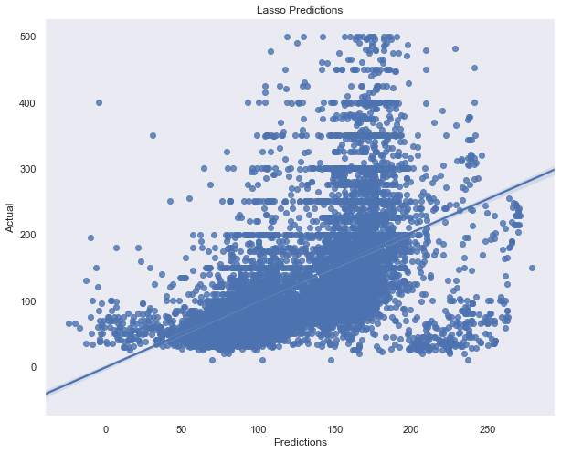

```python
plt.figure(figsize=(10,8))
sns.regplot(y_pred_lasso,y_test)
plt.xlabel('Predictions')
plt.ylabel('Actual')
plt.title("Lasso Predictions")
plt.grid(False)
plt.show()
```

```python
#Ridge
ridge = Ridge(alpha=1)
y_pred_ridge = ridge.fit(x_train, y_train).predict(x_test)
r2_score_ridge = r2_score(y_test, y_pred_ridge)
print(ridge)
print("ridge.coef_: {}".format(ridge.coef_))
print("ridge.intercept_: {}".format(ridge.intercept_))
print("r^2 on test data : %f" % r2_score_ridge)
print('MAE: %f'% mean_absolute_error(y_test, y_pred_ridge))
print('RMSE: %f'% np.sqrt(mean_squared_error(y_test, y_pred_ridge)))
```

```
Ridge(alpha=1, copy_X=True, fit_intercept=True, max_iter=None, normalize=False,
      random_state=None, solver='auto', tol=0.001)
ridge.coef_: [-7.03679565e-01  1.42508531e+02 -4.26579631e+02  6.45382585e+01
 -2.05433315e-01 -7.08864199e-02  1.26098050e-01  2.24279913e-01
  6.54423722e-02]
ridge.intercept_: -37262.009946608414
r^2 on test data : 0.285928
MAE: 49.968560
RMSE: 72.715808
```

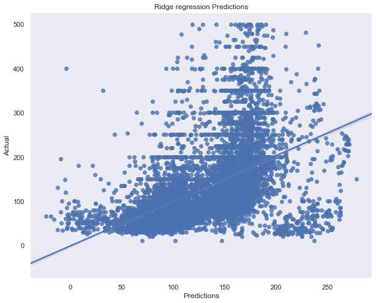

```python
plt.figure(figsize=(10,8))
sns.regplot(y_pred_ridge,y_test)
plt.xlabel('Predictions')
plt.ylabel('Actual')
plt.title("Ridge regression Predictions")
plt.grid(False)
plt.show()
```

```python
#ElasticNet
enet = ElasticNet(alpha=0.0005, l1_ratio=0.5)
y_pred_enet = enet.fit(x_train, y_train).predict(x_test)
r2_score_enet = r2_score(y_test, y_pred_enet)
print(enet)
print("enet.coef_: {}".format(enet.coef_))
print("enet.intercept_: {}".format(enet.intercept_))
print("r^2 on test data : %f" % r2_score_enet)
print('MAE: %f'% mean_absolute_error(y_test, y_pred_enet))
print('RMSE: %f'% np.sqrt(mean_squared_error(y_test, y_pred_enet)))
```

```
ElasticNet(alpha=0.0005, copy_X=True, fit_intercept=True, l1_ratio=0.5,
           max_iter=1000, normalize=False, positive=False, precompute=False,
           random_state=None, selection='cyclic', tol=0.0001, warm_start=False)
enet.coef_: [-9.66362075e-01  1.31314258e+02 -3.81952115e+02  6.50058738e+01
 -2.00528510e-01 -6.83927660e-02 -4.54433724e-02  2.32485025e-01
  6.37333925e-02]
enet.intercept_: -33505.633315594336
r^2 on test data : 0.284289
MAE: 49.959136
RMSE: 72.799221
```

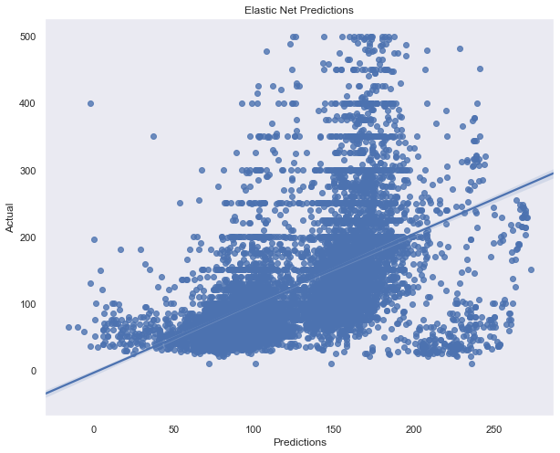

```python
plt.figure(figsize=(10,8))
sns.regplot(y_pred_enet,y_test)
plt.xlabel('Predictions')
plt.ylabel('Actual')
plt.title("Elastic Net Predictions")
plt.grid(False)
plt.show()
```

There is no significant differences between four regression models. From the coefficients graph,it also has no significant difference. Compared these four models, linear regression model has the lowest RMSE value. Therefore, I choose linear regression model as the final one.

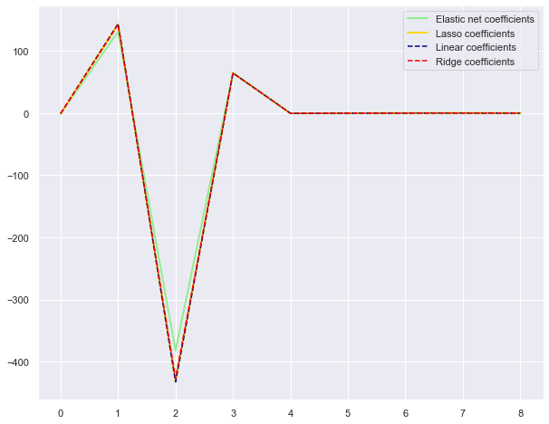

```python
plt.plot(enet.coef_, color='lightgreen', linewidth=2,
         label='Elastic net coefficients')
plt.plot(lasso.coef_, color='gold', linewidth=2,
         label='Lasso coefficients')
plt.plot(reg.coef_, '--', color='navy', label='Linear coefficients')
plt.plot(ridge.coef_, '--', color = 'red', label = 'Ridge coefficients')
plt.legend(loc='best')
plt.show()
```

```python
#Linear
reg=LinearRegression()
reg.fit(x_train,y_train)
y_pred=reg.predict(x_test)
from sklearn.metrics import r2_score
print(r2_score(y_test,y_pred))
print("reg.coef_: {}".format(reg.coef_))
print("reg.intercept_: {}".format(reg.intercept_))
print('MAE: %f'% mean_absolute_error(y_test,y_pred))
print('RMSE: %f'% np.sqrt(mean_squared_error(y_test,y_pred)))
print('r^2 on test data %f' % r2_score(y_test,y_pred))
```

```
0.2860622005497955
reg.coef_: [-6.66335274e-01  1.43920731e+02 -4.32491651e+02  6.44753695e+01
 -2.06075203e-01 -7.12144816e-02  1.48690973e-01  2.23195395e-01
  6.56661425e-02]
reg.intercept_: -37756.75434735461
MAE: 49.972716
RMSE: 72.708965
r^2 on test data 0.286062
```

The result shows the relationship between price and nine independent variables. Overall, the fit of coefficient of determination is weak, with 0.28 r-square value.There is only 28% accommodation fitting the model.But we still can find some relationships between price and independent variables from coefficients.

### Conclusion

Some limitations of the study needs to be considered. First, the goodness of fit is weak. The most important reason is that this study only consider the variables within the dataset.Some scholar fins that the price of Airbnb accommodations depend on host reputations, cancellation policy and local amenities. What`s more, for commercial accommodations, the needs of customers are also important. It is related to other external characteristics, like transportation, tourist sites(Falk, Larpin and Scaglione, 2019).

### Reference

Chattopadhyay, M. and Mitra, S., 2019. Do airbnb host listing attributes influence room pricing homogenously?. International Journal of Hospitality Management, 81, pp.54-64.

Chen, Y. and Xie, K., 2017. Consumer valuation of Airbnb listings: a hedonic pricing approach. International Journal of Contemporary Hospitality Management, 29(9), pp.2405-2424.

Falk, M., Larpin, B. and Scaglione, M., 2019. The role of specific attributes in determining prices of Airbnb listings in rural and urban locations. International Journal of Hospitality Management, 83, pp.132-140.